# Racial Bias in Gifted and Talented Programs: Executive Summary

Alexandra Chang

### Overview

For my final project, I conducted an exploratory data analysis (EDA) on data from the [Civil Rights Data Collection (CRDC)](https://www2.ed.gov/about/offices/list/ocr/docs/crdc-2017-18.html) — a biennial study conducted by the Office for Civil Rights within the U.S. Department of Education — for the 2017-2018 school year. In this EDA, I sought to visualize the racial disparities that exist in Gifted and Talented (GAT) programs across the United States, specifically the underrepresentation of BIPOC students in GAT programs.

The CRDC collects “a variety of information including student enrollment and educational programs and services, most of which is disaggregated by race/ethnicity, sex, limited English proficiency, and disability.” For this project, I used two data sets from the CRDC: `Enrollment.csv` and `Gifted and Talented.csv`.

### Summary of key findings

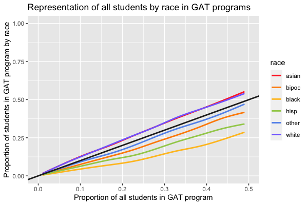

alt text

This visualization is a facetted graph that divides our jitter plot into six subplots by `race`. This graph is a second way to represent our findings from above but separated by `race`. Each point on this graph represents an individual school. By including a line of identity $y=x$ on each subplot, we can compare the (in)equality of representation in GAT programs by race. If students were equally represented in GAT programs independent of their `race`, each trend line would lie exactly along the line $y=x$.

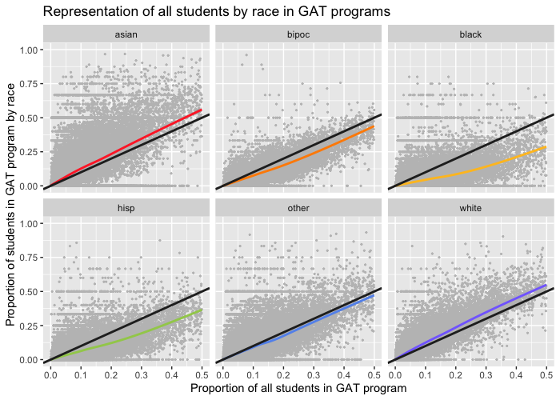

alt text